# Assignment 6

Guillermo Mercon

2022-07-24

```r
# Add any packages you want in this chunk:

library(readr)
library(gvlma)
library(MASS)
library(leaps)
library(car)
```

We are going to look at the property prices for Orange County. From there we are going to try and predict the sales price by linear regression.

# 1 Importing Data

Bring in the data and make sure the data types are correct. If not, make the proper changes. The file is located within this project. *data/prop_prices_reduced.csv*

```r
prop_prices_reduced <- read_csv("data/prop_prices_reduced.csv")
View(prop_prices_reduced)

prop_prices_reduced$sale_def <- prop_prices_reduced$sale_def/1000

attach(prop_prices_reduced)
```

- Here I changed sale_def and scaled those prices down by 1000. This will help the scale of the graphs later so the x and y borders are not so large.

# 2 Plotting

Plot histograms for all variables. Additionally, add scatter plots for the relationships between all quantitative variables.

- Here I included all the histograms and a scatterplot which has all relationships between each variable on one page. I also included some of the more important scatterplots, mainly the deflated sales by each variable.

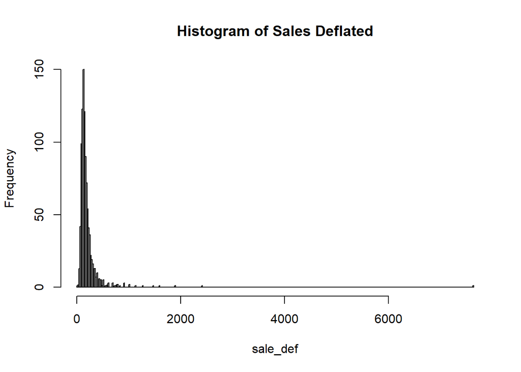

```r
hist(sale_def, breaks = "fd",main = "Histogram of Sales Deflated")
```

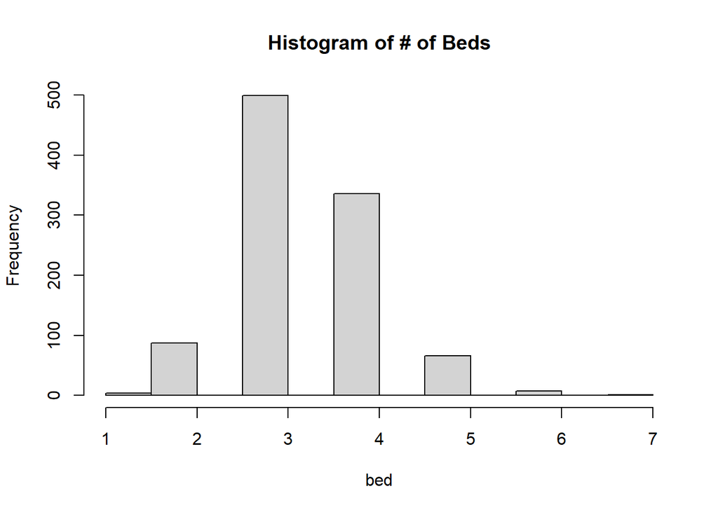

```r
hist(bed, main = "Histogram of # of Beds")
```

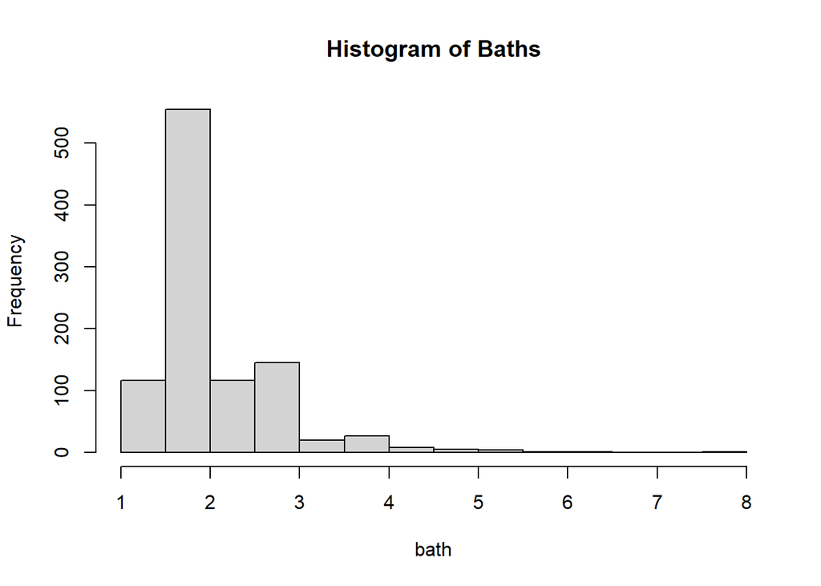

```r
hist(bath, main = "Histogram of Baths")
```

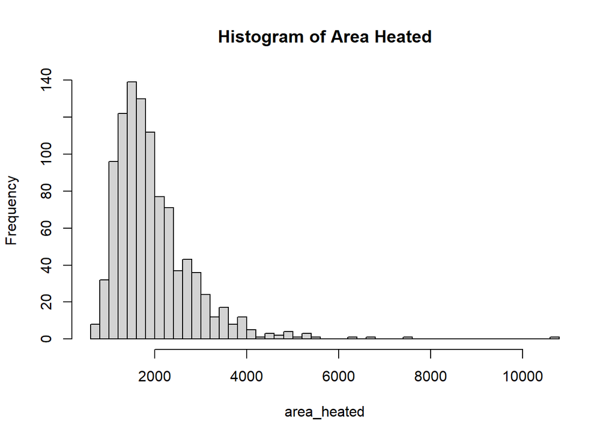

```r
hist(area_heated,breaks = "fd", main = "Histogram of Area Heated")
```

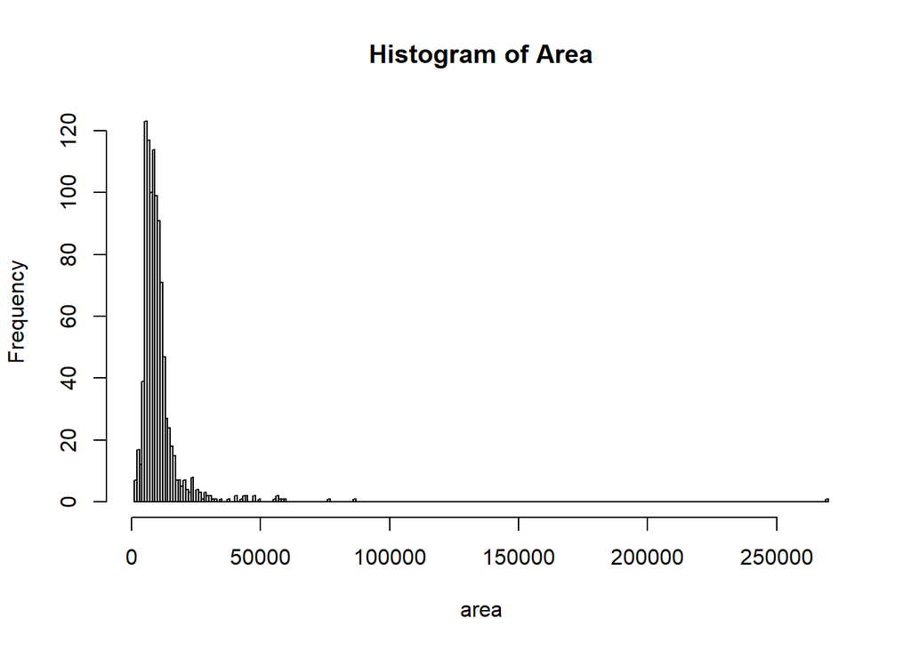

```r
hist(area,breaks = "fd", main = "Histogram of Area")
```

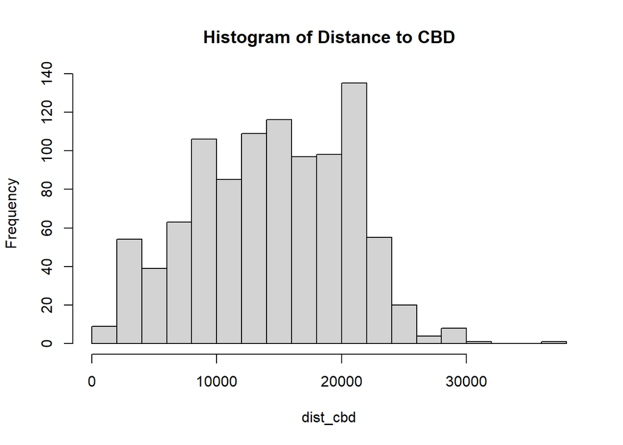

```r
hist(dist_cbd,breaks = "fd", main = "Histogram of Distance to CBD")
```

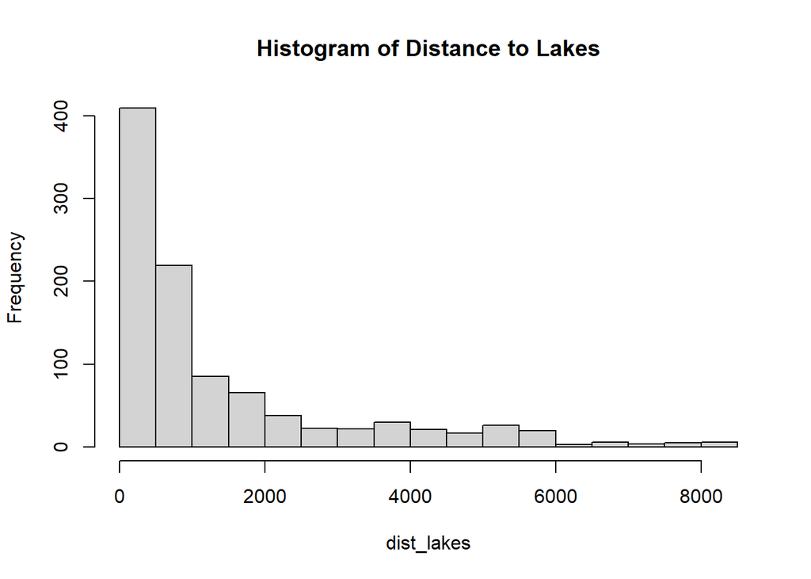

```r
hist(dist_lakes,breaks = "fd", main = "Histogram of Distance to Lakes")
```

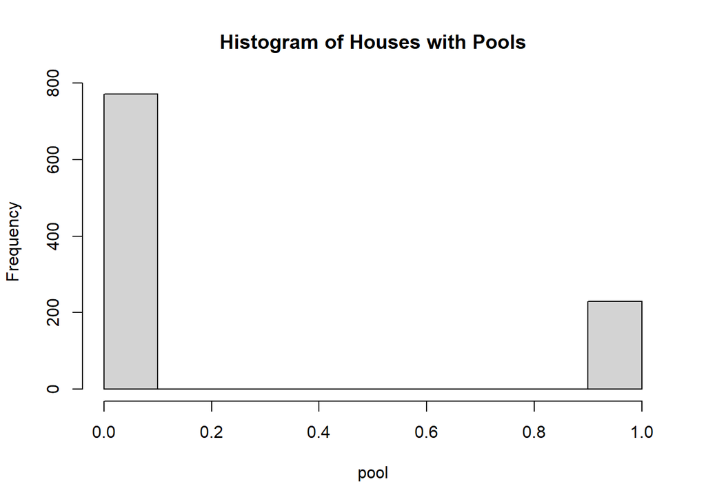

```r
hist(pool, main = "Histogram of Houses with Pools")
```

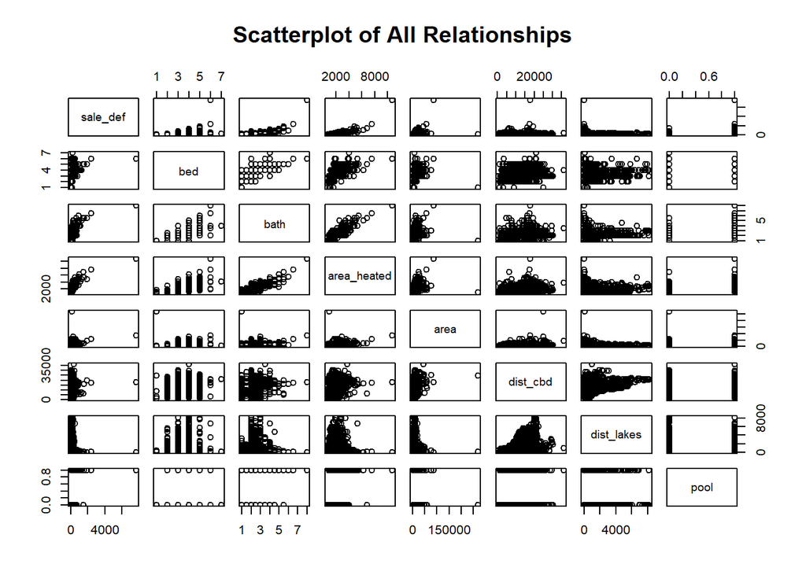

```r
plot(prop_prices_reduced, main = "Scatterplot of All Relationships")
```

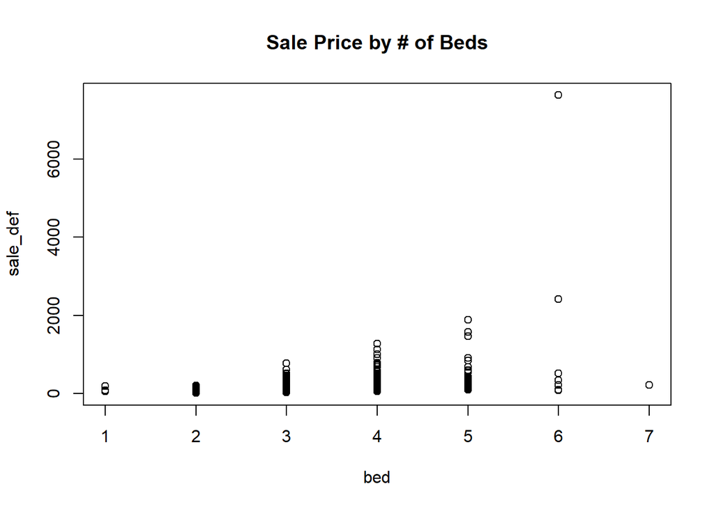

```r
plot(bed,sale_def, main = "Sale Price by # of Beds")
```

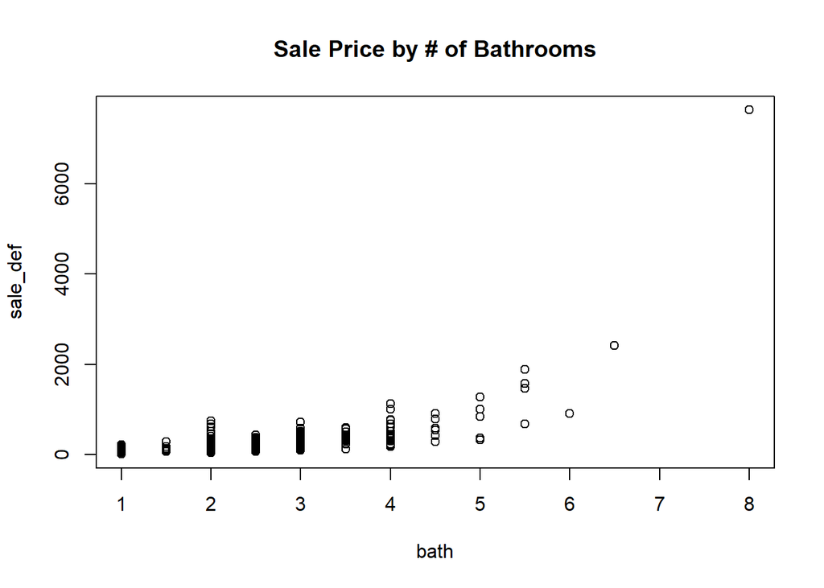

```r
plot(bath,sale_def, main = "Sale Price by # of Bathrooms")
```

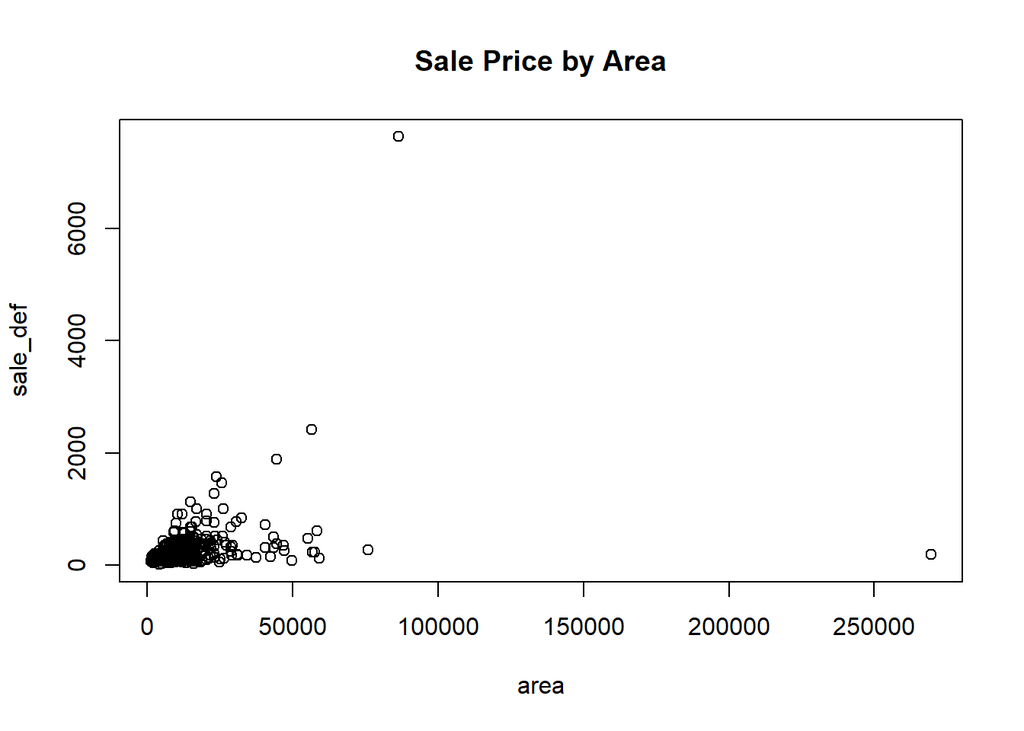

```r
plot(area,sale_def, main = "Sale Price by Area")
```

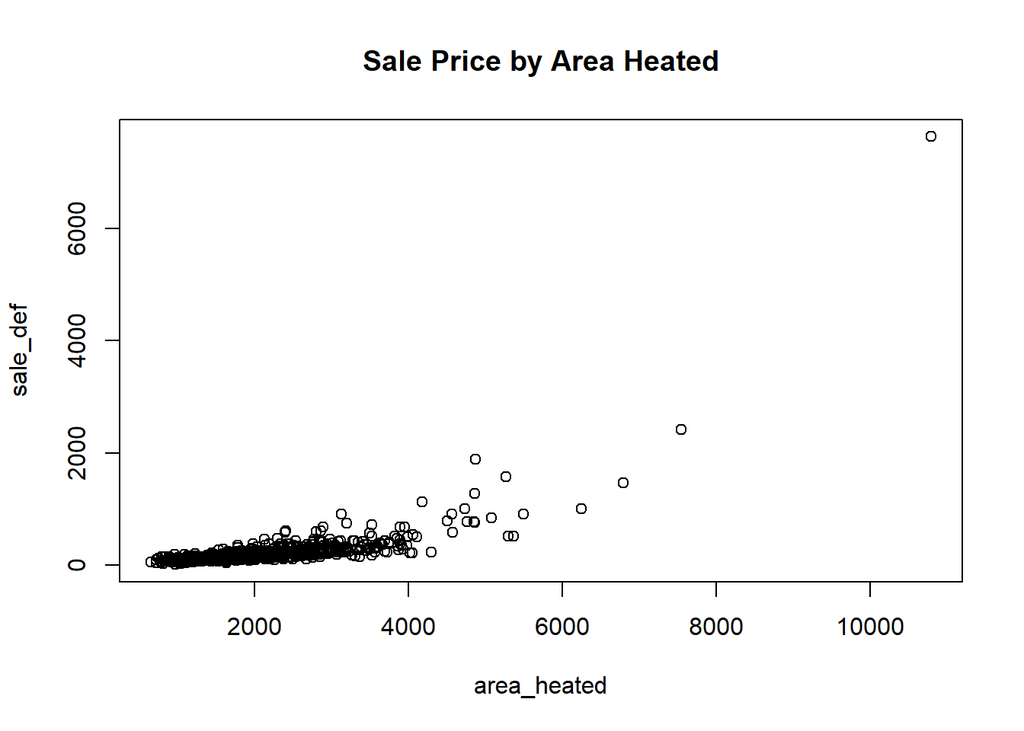

```r
plot(area_heated,sale_def, main = "Sale Price by Area Heated")
```

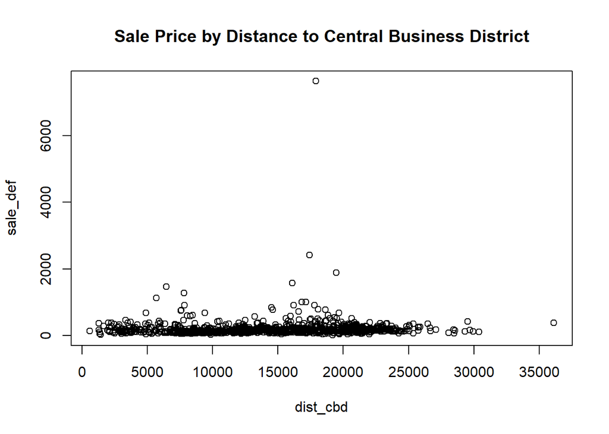

```r
plot(dist_cbd,sale_def, main = "Sale Price by Distance to Central Business District")
```

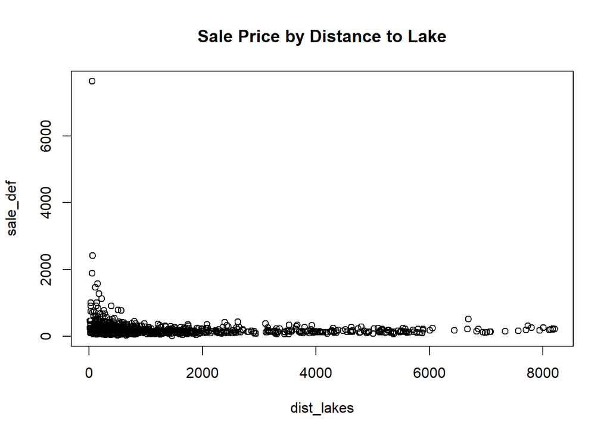

```r
plot(dist_lakes,sale_def, main = "Sale Price by Distance to Lake")
```

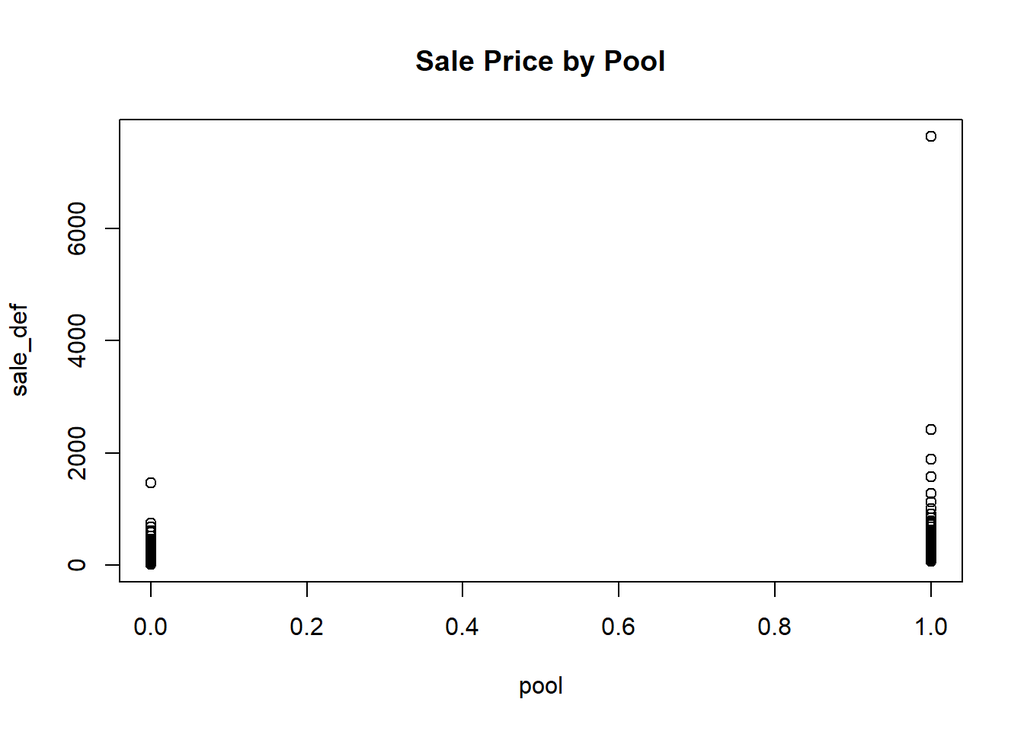

```r
plot(pool,sale_def, main = "Sale Price by Pool")
```

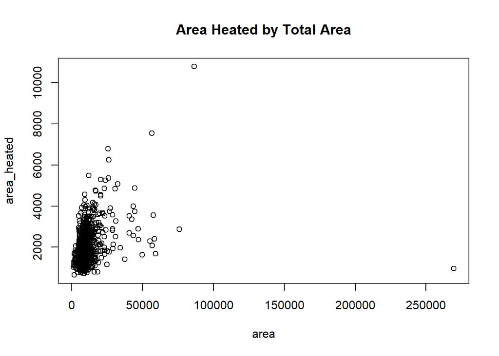

```r
plot(area,area_heated, main = "Area Heated by Total Area")
```

# 3 Summary Statistics

Provide basic summary statistics for univariate analysis. Also, provide the correlation between all the quantitative variables.

```r
summary(prop_prices_reduced)
```

```
##     sale_def           bed             bath        area_heated
##  Min.   :  15.3   Min.   :1.000   Min.   :1.000   Min.   :  650
##  1st Qu.: 115.6   1st Qu.:3.000   1st Qu.:2.000   1st Qu.: 1387
##  Median : 151.1   Median :3.000   Median :2.000   Median : 1744
##  Mean   : 200.3   Mean   :3.398   Mean   :2.248   Mean   : 1955
##  3rd Qu.: 213.9   3rd Qu.:4.000   3rd Qu.:2.500   3rd Qu.: 2301
##  Max.   :7630.0   Max.   :7.000   Max.   :8.000   Max.   :10796
##       area           dist_cbd         dist_lakes           pool
##  Min.   :  1307   Min.   :  598.2   Min.   :  16.74   Min.   :0.000
##  1st Qu.:  6498   1st Qu.: 9701.7   1st Qu.: 314.86   1st Qu.:0.000
##  Median :  8733   Median :14552.0   Median : 638.82   Median :0.000
##  Mean   : 10565   Mean   :14382.9   Mean   :1403.54   Mean   :0.229
##  3rd Qu.: 11250   3rd Qu.:19369.2   3rd Qu.:1735.35   3rd Qu.:0.000
##  Max.   :269496   Max.   :36107.6   Max.   :8206.79   Max.   :1.000
```

```r
# what about spread? sd/var
cor(prop_prices_reduced)
```

```
##                sale_def        bed        bath area_heated        area
## sale_def     1.00000000 0.32557109  0.58731596  0.69201080  0.34354392
## bed          0.32557109 1.00000000  0.64449531  0.66911599  0.10437035
## bath         0.58731596 0.64449531  1.00000000  0.83255359  0.19298319
## area_heated  0.69201080 0.66911599  0.83255359  1.00000000  0.30184325
## area         0.34354392 0.10437035  0.19298319  0.30184325  1.00000000
## dist_cbd     0.05263700 0.23328277  0.24220637  0.25494517  0.08648327
## dist_lakes  -0.08857844 0.03747888 -0.02109154 -0.04092947 -0.15432291
## pool         0.27749823 0.31299930  0.38722523  0.43899880  0.19200110
##               dist_cbd  dist_lakes        pool
## sale_def    0.05263700 -0.08857844  0.27749823
## bed         0.23328277  0.03747888  0.31299930
## bath        0.24220637 -0.02109154  0.38722523
## area_heated 0.25494517 -0.04092947  0.43899880
## area        0.08648327 -0.15432291  0.19200110
## dist_cbd    1.00000000  0.26520451  0.11442899
## dist_lakes  0.26520451  1.00000000 -0.04295257
## pool        0.11442899 -0.04295257  1.00000000
```

# 4 Regression Analysis

Run a regression with all the variables included. Print results of the regression.

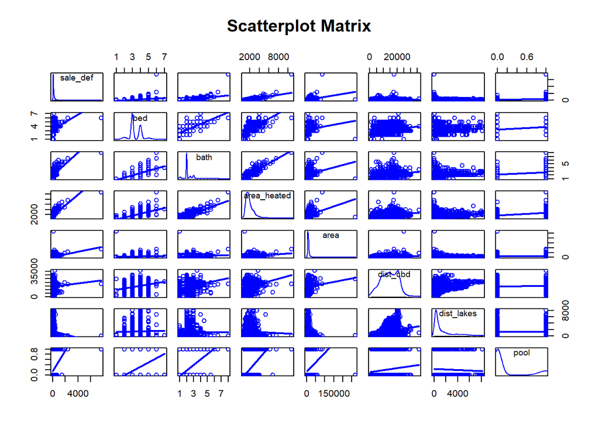

```r
scatterplotMatrix(prop_prices_reduced, smooth = FALSE, main = "Scatterplot Matrix")
```

```r
fit <-lm(sale_def ~ bed + bath + area_heated + area + dist_cbd + dist_lakes + pool,data = prop_prices_reduced)

summary(fit)
```

```
##
## Call:
## lm(formula = sale_def ~ bed + bath + area_heated + area + dist_cbd +
##     dist_lakes + pool, data = prop_prices_reduced)
##
## Residuals:
##    Min     1Q Median     3Q    Max
## -765.2  -56.0    9.8   63.8 4954.8
##
## Coefficients:
##               Estimate Std. Error t value Pr(>|t|)
## (Intercept) -5.890e+01  3.093e+01  -1.904 0.057170 .
## bed         -8.492e+01  1.087e+01  -7.810 1.45e-14 ***
## bath         5.449e+01  1.507e+01   3.616 0.000315 ***
## area_heated  2.439e-01  1.430e-02  17.054  < 2e-16 ***
## area         3.548e-03  5.958e-04   5.955 3.61e-09 ***
## dist_cbd    -5.849e-03  1.090e-03  -5.366 1.00e-07 ***
## dist_lakes   9.651e-04  3.810e-03   0.253 0.800091
## pool        -2.776e+01  1.640e+01  -1.693 0.090787 .
## ---
## Signif. codes:  0 '***' 0.001 '**' 0.01 '*' 0.05 '.' 0.1 ' ' 1
##
## Residual standard error: 194.9 on 992 degrees of freedom
## Multiple R-squared:  0.547,  Adjusted R-squared:  0.5438
## F-statistic: 171.2 on 7 and 992 DF,  p-value: < 2.2e-16
```

Which of the variables tested significant at the 95% level? Looking at the results and answering outside of the chunk is sufficient.

`Pool actually didn't test significant at 95%`

## 4.1 Evaluating the model

As is, are any of the Gauss-Markov assumptions violated? If so, which ones? How can you fix the issues?

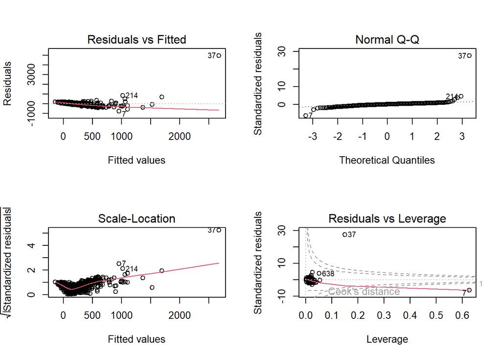

```r
opar <- par(no.readonly = TRUE)

par(mfrow = c(2, 2))
plot(fit)
```

```r
par(opar)

durbinWatsonTest(fit)
```

```
##  lag Autocorrelation D-W Statistic p-value
##    1    -0.008920317      2.017485    0.68
##  Alternative hypothesis: rho != 0
```

```r
gvmodel <- gvlma(fit)
summary(gvmodel)
```

```
##
## Call:
## lm(formula = sale_def ~ bed + bath + area_heated + area + dist_cbd +
##     dist_lakes + pool, data = prop_prices_reduced)
##
## Residuals:
##    Min     1Q Median     3Q    Max
## -765.2  -56.0    9.8   63.8 4954.8
##
## Coefficients:
##               Estimate Std. Error t value Pr(>|t|)
## (Intercept) -5.890e+01  3.093e+01  -1.904 0.057170 .
## bed         -8.492e+01  1.087e+01  -7.810 1.45e-14 ***
## bath         5.449e+01  1.507e+01   3.616 0.000315 ***
## area_heated  2.439e-01  1.430e-02  17.054  < 2e-16 ***
## area         3.548e-03  5.958e-04   5.955 3.61e-09 ***
## dist_cbd    -5.849e-03  1.090e-03  -5.366 1.00e-07 ***
## dist_lakes   9.651e-04  3.810e-03   0.253 0.800091
## pool        -2.776e+01  1.640e+01  -1.693 0.090787 .
## ---
## Signif. codes:  0 '***' 0.001 '**' 0.01 '*' 0.05 '.' 0.1 ' ' 1
##
## Residual standard error: 194.9 on 992 degrees of freedom
## Multiple R-squared:  0.547,  Adjusted R-squared:  0.5438
## F-statistic: 171.2 on 7 and 992 DF,  p-value: < 2.2e-16
##
##
## ASSESSMENT OF THE LINEAR MODEL ASSUMPTIONS
## USING THE GLOBAL TEST ON 4 DEGREES-OF-FREEDOM:
## Level of Significance =  0.05
##
## Call:
##  gvlma(x = fit)
##
##                        Value p-value                   Decision
## Global Stat        7497980.4       0 Assumptions NOT satisfied!
## Skewness             45659.6       0 Assumptions NOT satisfied!
## Kurtosis           7450926.5       0 Assumptions NOT satisfied!
## Link Function          782.2       0 Assumptions NOT satisfied!
## Heteroscedasticity     612.1       0 Assumptions NOT satisfied!
```

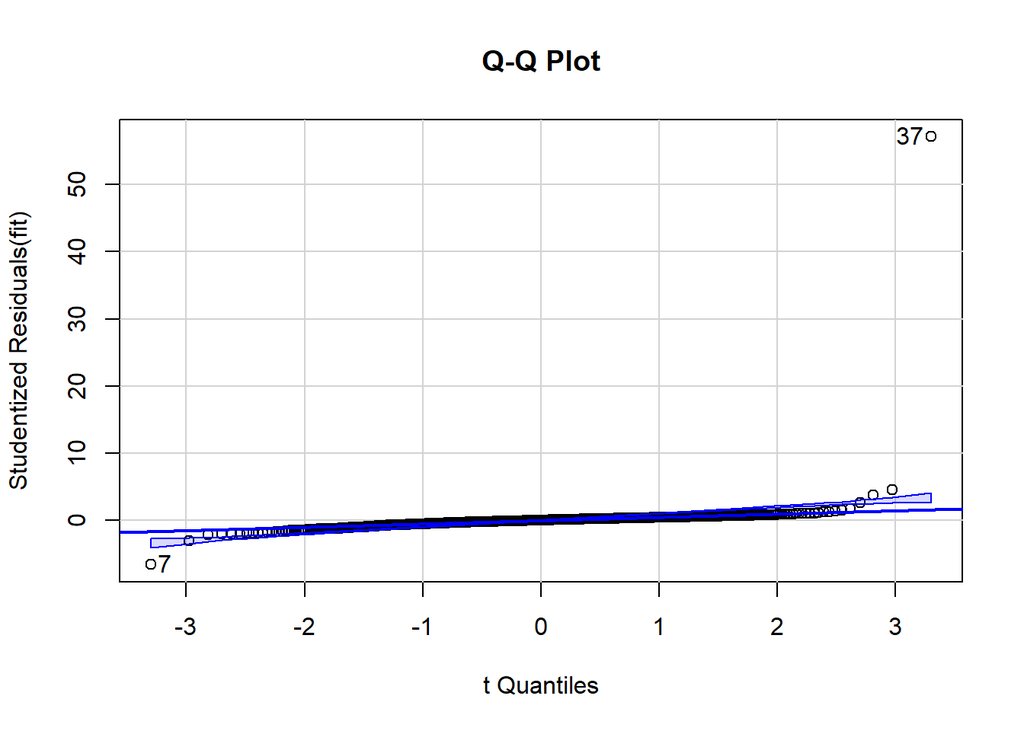

```
## [1]  7 37
```

```r
qqPlot(fit, labels = FALSE, simulate = TRUE, main = "Q-Q Plot")
```

- It appears as though we have an outlier at index number 37. This appears to be causing a violation of Gauss Markov assumption #1. If we remove this outlier we will be studying a more homogenous sample.
- We also see that distance to lakes is not significant. This is a violation of Gauss Markov assumption #3. I will adjust this by trying several variations. First we will change “distance to lakes” to a percentage by dividing the distance by the mean distance to lakes. I will then try to change the formula so that distance to lakes is included as a quadratic variable. Finally I will take the original formula and take the log of the deflated sales and the log of the distance to lakes. I will then compare the two formulas to see which has a higher R^2 and more significance.

`What about 2, 4, and 5`

## 4.2 New Model

Based off of your findings in the previous section, make changes to the variables, the functional form, etc.

```r
newdata <- prop_prices_reduced[-c(37),]
newdata$dist_lakes <- newdata$dist_lakes/mean(newdata$dist_lakes)


newfit1 <-  lm(sale_def ~ bed + bath + area_heated + area + dist_cbd + dist_lakes + pool + I(dist_lakes^2),data = newdata)
summary(newfit1)
```

```
##
## Call:
## lm(formula = sale_def ~ bed + bath + area_heated + area + dist_cbd +
##     dist_lakes + pool + I(dist_lakes^2), data = newdata)
##
## Residuals:
##     Min      1Q  Median      3Q     Max
## -281.58  -41.72    0.54   35.34 1213.95
##
## Coefficients:
##                   Estimate Std. Error t value Pr(>|t|)
## (Intercept)     -1.756e+01  1.538e+01  -1.142   0.2537
## bed             -4.526e+01  5.295e+00  -8.548  < 2e-16 ***
## bath             5.651e+01  7.287e+00   7.755 2.19e-14 ***
## area_heated      1.436e-01  7.182e-03  19.996  < 2e-16 ***
## area             1.463e-03  2.907e-04   5.034 5.71e-07 ***
## dist_cbd        -3.759e-03  5.298e-04  -7.095 2.46e-12 ***
## dist_lakes      -1.351e+01  7.874e+00  -1.716   0.0864 .
## pool             1.916e+01  7.959e+00   2.407   0.0163 *
## I(dist_lakes^2)  2.298e+00  1.730e+00   1.329   0.1842
## ---
## Signif. codes:  0 '***' 0.001 '**' 0.01 '*' 0.05 '.' 0.1 ' ' 1
##
## Residual standard error: 94.08 on 990 degrees of freedom
## Multiple R-squared:  0.6862, Adjusted R-squared:  0.6837
## F-statistic: 270.6 on 8 and 990 DF,  p-value: < 2.2e-16
```

```r
newfit2 <-  lm(log(sale_def) ~ bed + bath + area_heated + area + dist_cbd + log(dist_lakes) + pool, data = newdata)
summary(newfit2)
```

```
##
## Call:
## lm(formula = log(sale_def) ~ bed + bath + area_heated + area +
##     dist_cbd + log(dist_lakes) + pool, data = newdata)
##
## Residuals:
##      Min       1Q   Median       3Q      Max
## -1.72664 -0.15869  0.00606  0.17284  1.03229
##
## Coefficients:
##                   Estimate Std. Error t value Pr(>|t|)
## (Intercept)      4.082e+00  4.514e-02  90.421  < 2e-16 ***
## bed             -4.199e-02  1.574e-02  -2.668 0.007756 **
## bath             1.255e-01  2.161e-02   5.809 8.48e-09 ***
## area_heated      4.506e-04  2.126e-05  21.189  < 2e-16 ***
## area             2.480e-06  8.696e-07   2.852 0.004438 **
## dist_cbd        -5.869e-06  1.587e-06  -3.699 0.000228 ***
## log(dist_lakes) -2.328e-02  7.874e-03  -2.957 0.003180 **
## pool             1.326e-01  2.363e-02   5.612 2.60e-08 ***
## ---
## Signif. codes:  0 '***' 0.001 '**' 0.01 '*' 0.05 '.' 0.1 ' ' 1
##
## Residual standard error: 0.2795 on 991 degrees of freedom
## Multiple R-squared:  0.7337, Adjusted R-squared:  0.7318
## F-statistic:   390 on 7 and 991 DF,  p-value: < 2.2e-16
```

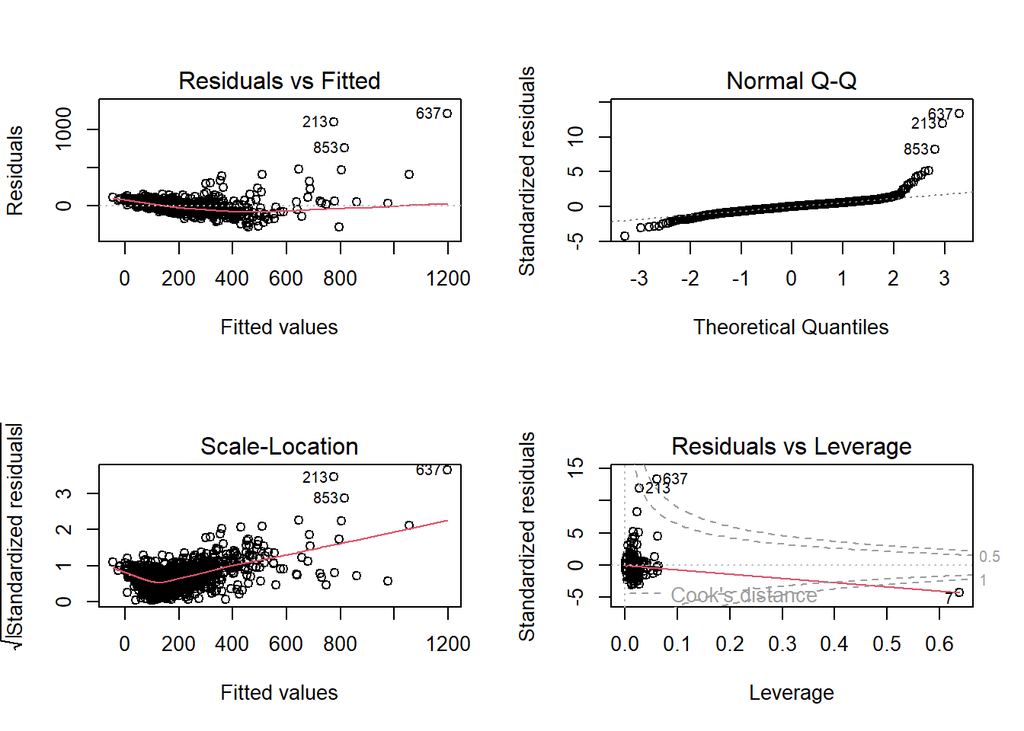

```r
par(mfrow = c(2, 2))
plot(newfit1)
```

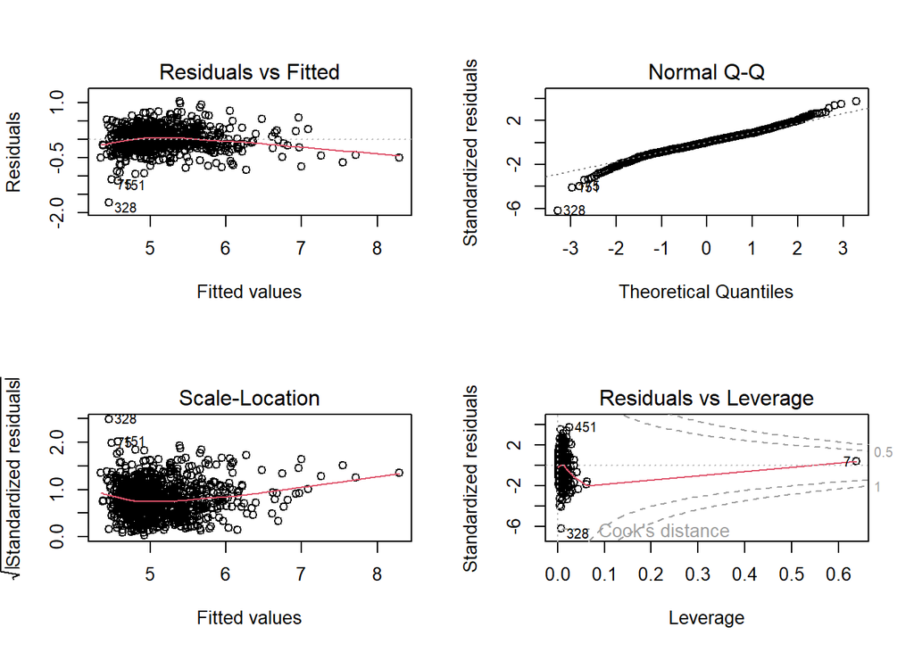

```r
par(mfrow = c(2, 2))
plot(newfit2)
```

```r
par(opar)

gvmodelnew1 <- gvlma(newfit1)
summary(gvmodelnew1)
```

```
##
## Call:
## lm(formula = sale_def ~ bed + bath + area_heated + area + dist_cbd +
##     dist_lakes + pool + I(dist_lakes^2), data = newdata)
##
## Residuals:
##     Min      1Q  Median      3Q     Max
## -281.58  -41.72    0.54   35.34 1213.95
##
## Coefficients:
##                   Estimate Std. Error t value Pr(>|t|)
## (Intercept)     -1.756e+01  1.538e+01  -1.142   0.2537
## bed             -4.526e+01  5.295e+00  -8.548  < 2e-16 ***
## bath             5.651e+01  7.287e+00   7.755 2.19e-14 ***
## area_heated      1.436e-01  7.182e-03  19.996  < 2e-16 ***
## area             1.463e-03  2.907e-04   5.034 5.71e-07 ***
## dist_cbd        -3.759e-03  5.298e-04  -7.095 2.46e-12 ***
## dist_lakes      -1.351e+01  7.874e+00  -1.716   0.0864 .
## pool             1.916e+01  7.959e+00   2.407   0.0163 *
## I(dist_lakes^2)  2.298e+00  1.730e+00   1.329   0.1842
## ---
## Signif. codes:  0 '***' 0.001 '**' 0.01 '*' 0.05 '.' 0.1 ' ' 1
##
## Residual standard error: 94.08 on 990 degrees of freedom
## Multiple R-squared:  0.6862, Adjusted R-squared:  0.6837
## F-statistic: 270.6 on 8 and 990 DF,  p-value: < 2.2e-16
##
##
## ASSESSMENT OF THE LINEAR MODEL ASSUMPTIONS
## USING THE GLOBAL TEST ON 4 DEGREES-OF-FREEDOM:
## Level of Significance =  0.05
##
## Call:
##  gvlma(x = newfit1)
##
##                        Value p-value                   Decision
## Global Stat        1.217e+05  0.0000 Assumptions NOT satisfied!
## Skewness           3.752e+03  0.0000 Assumptions NOT satisfied!
## Kurtosis           1.176e+05  0.0000 Assumptions NOT satisfied!
## Link Function      3.548e+02  0.0000 Assumptions NOT satisfied!
## Heteroscedasticity 5.065e-01  0.4767    Assumptions acceptable.
```

```r
gvmodelnew2 <- gvlma(newfit2)
summary(gvmodelnew2)
```

```
##
## Call:
## lm(formula = log(sale_def) ~ bed + bath + area_heated + area +
##     dist_cbd + log(dist_lakes) + pool, data = newdata)
##
## Residuals:
##      Min       1Q   Median       3Q      Max
## -1.72664 -0.15869  0.00606  0.17284  1.03229
##
## Coefficients:
##                   Estimate Std. Error t value Pr(>|t|)
## (Intercept)      4.082e+00  4.514e-02  90.421  < 2e-16 ***
## bed             -4.199e-02  1.574e-02  -2.668 0.007756 **
## bath             1.255e-01  2.161e-02   5.809 8.48e-09 ***
## area_heated      4.506e-04  2.126e-05  21.189  < 2e-16 ***
## area             2.480e-06  8.696e-07   2.852 0.004438 **
## dist_cbd        -5.869e-06  1.587e-06  -3.699 0.000228 ***
## log(dist_lakes) -2.328e-02  7.874e-03  -2.957 0.003180 **
## pool             1.326e-01  2.363e-02   5.612 2.60e-08 ***
## ---
## Signif. codes:  0 '***' 0.001 '**' 0.01 '*' 0.05 '.' 0.1 ' ' 1
##
## Residual standard error: 0.2795 on 991 degrees of freedom
## Multiple R-squared:  0.7337, Adjusted R-squared:  0.7318
## F-statistic:   390 on 7 and 991 DF,  p-value: < 2.2e-16
##
##
## ASSESSMENT OF THE LINEAR MODEL ASSUMPTIONS
## USING THE GLOBAL TEST ON 4 DEGREES-OF-FREEDOM:
## Level of Significance =  0.05
##
## Call:
##  gvlma(x = newfit2)
##
##                      Value   p-value                   Decision
## Global Stat        311.035 0.000e+00 Assumptions NOT satisfied!
## Skewness            19.671 9.197e-06 Assumptions NOT satisfied!
## Kurtosis           251.463 0.000e+00 Assumptions NOT satisfied!
## Link Function       37.778 7.925e-10 Assumptions NOT satisfied!
## Heteroscedasticity   2.122 1.452e-01    Assumptions acceptable.
```

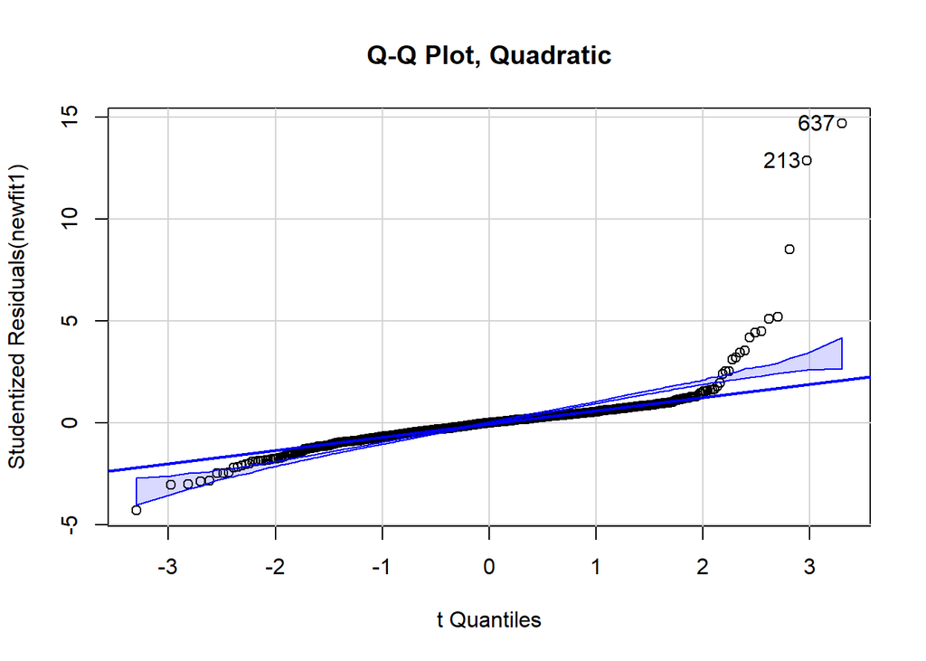

```
## [1] 213 637
```

```r
qqPlot(newfit1, labels = FALSE, simulate = TRUE, main = "Q-Q Plot, Quadratic")
```

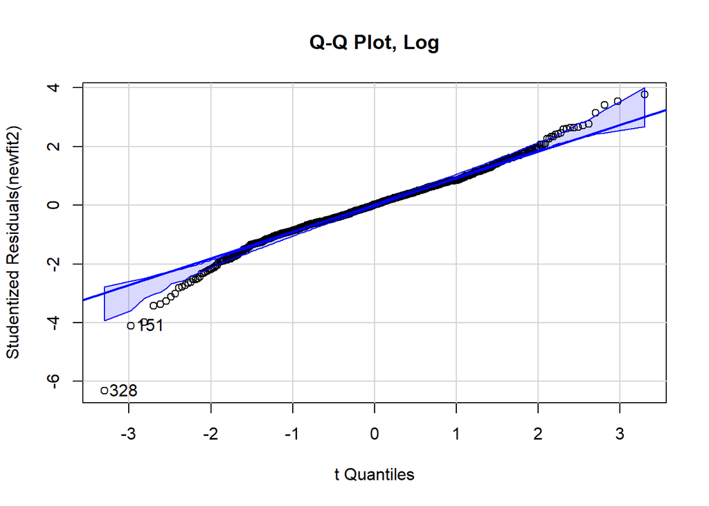

```
## [1] 151 328
```

```r
qqPlot(newfit2, labels = FALSE, simulate = TRUE, main = "Q-Q Plot, Log")
```

- It appears as though the quadratic transformation brought the adjusted R squared up to .68 while the log transformation brought it up to .73. The log transformation also brings up the significance of distance to lakes to above 95%. It also brings the residuals vs fitted values down to a much smaller error window, between 1 and -2. Overall the log transformation helps the fit of the regression model significantly. Even then not all gvmodel assumptions are corrected for.

# 5 Prediction

Based on the following inputs, predict the deflated sales price:

- 2 bed
- 2 bath
- area_heated = 1223
- area = 9750
- dist_cbd = 19368
- dist_lakes = 490
- no pool

```r
newhouse <- data.frame("bed" = 2,
                       "bath" = 2,
                       "area_heated"= 1223,
                       "area" = 9750,
                       "dist_cbd" = 19368,
                       "dist_lakes" = 490,
                       "pool" = 0)
predict(newfit2, newhouse)
```

```
##        1
## 4.566142
```

```r
exp(4.566142)
```

```
## [1] 96.17236
```

- The predicted log(sales price) is 4.566142. The actual value of the sales price would be $96,172.